# Value at Risk oraz Estimated Shortfall

Karol Szpyt

7 kwietnia 2019

# Wstęp

## Przegląd danych

Poniższa praca ma na celu pokazanie różnych metod liczenia **value at risk** oraz **estimated shortfall**. Wyliczenia oparte będą o autentyczne dane historyczne- kursy walut. Wybrane zostaną 3 waluty- **dolar amerykański**, **hrywna ukraińska** oraz **frank szwajcarski**.  
Do dalszych obliczeń potrzebne będą stopy zwrotu. Użyte zostaną logarytmiczne, dzienne stopy zwrotu, podane wzorem: ${\Large S_n = ln(\frac{w_n}{w_{n-1}})}$, gdzie $S_n$ to stopa zwrotu w n-tym dniu, a $w_n$ to wartość waluty w n-tym dniu.

Wykresy wahań kursów walut:

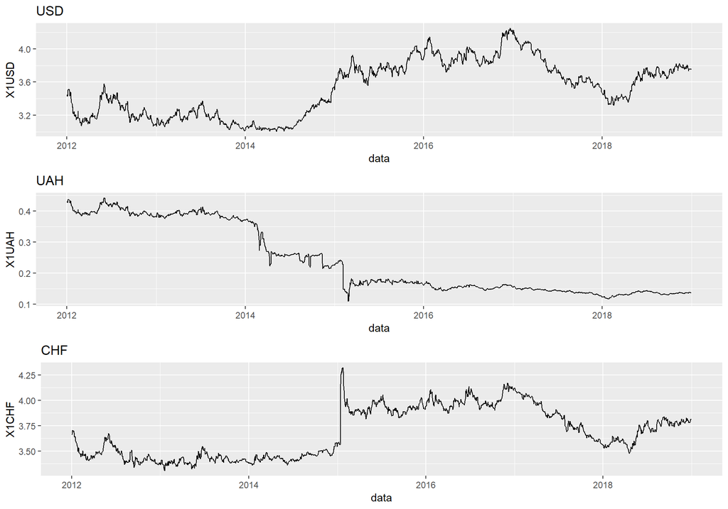

| Statystyki Opisowe | Statystyki Opisowe USD | Statystyki Opisowe UAH | Statystyki Opisowe CHF |  |
| --- | --- | --- | --- | --- |
| Min. | 3.0042000 | 0.1094000 | 3.3067000 |  |
| 1st Qu. | 3.1890000 | 0.1452000 | 3.4448750 |  |
| Median | 3.5747000 | 0.1708500 | 3.6435000 |  |
| Mean | 3.5260387 | 0.2377248 | 3.6833080 |  |
| 3rd Qu. | 3.7858250 | 0.3799750 | 3.9129500 |  |
| Max. | 4.2493000 | 0.4420000 | 4.3223000 |  |
| wsp.zm. | 0.0947566 | 0.4630604 | 0.0664048 |  |

| Macierz korelacji | Macierz korelacji USD | Macierz korelacji UAH | Macierz korelacji CHF |  |
| --- | --- | --- | --- | --- |
| USD | 1.0000000 | 0.9515803 | -0.7496423 |  |
| UAH | 0.9515803 | 1.0000000 | -0.7353548 |  |
| CHF | -0.7496423 | -0.7353548 | 1.0000000 |  |

## Stopy zwrotu

Funckja do wyliczania dziennych stóp zwrotu (w procentach):

```r
returnrate.daily.log <- function(v)
{
  v1 <- c(1, v)
  v <- c(v, 1)
  v2 <- (v/v1)[-c(1, length(v/v1))]
  return(log(v2) * 100)
}
```

Ze stóp zwrotu tworzona jest funkcja straty poprzez pomnożenie wartości przez $-1$

```r
rr.usd <- -returnrate.daily.log(data$X1USD)
rr.uah <- -returnrate.daily.log(data$X1UAH)
rr.chf <- -returnrate.daily.log(data$X1CHF)
```

| date | rr.usd | rr.uah | rr.chf |
| --- | --- | --- | --- |
| 2012-01-03 | 0.5150526 | 0.0930665 | 0.1255287 |
| 2012-01-04 | -0.1253699 | 0.7945824 | -0.2509001 |
| 2012-01-05 | -2.1931399 | -2.2962855 | -0.8759259 |
| 2012-01-09 | -0.1964945 | 0.0229331 | 0.2622438 |
| 2012-01-10 | 0.1907936 | -0.0917011 | -0.2028261 |
| 2012-01-11 | 0.4685589 | 0.5053997 | 0.5635191 |

Oraz wykresy poszczególnych stóp zworów. Dla przypomnienia, dodatnie wartości to straty.

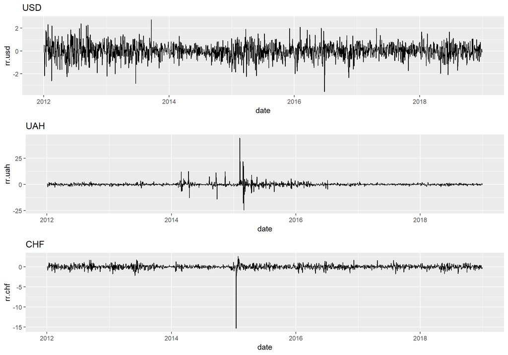

| Statystyki Opisowe | Statystyki Opisowe USD | Statystyki Opisowe UAH | Statystyki Opisowe CHF |  |
| --- | --- | --- | --- | --- |
| Min. | -3.5658530 | -24.3375455 | -15.2877789 |  |
| 1st Qu. | -0.3729771 | -0.4400651 | -0.2527915 |  |
| Median | 0.0059296 | 0.0000000 | 0.0187872 |  |
| Mean | -0.0049517 | 0.0654191 | -0.0022712 |  |
| 3rd Qu. | 0.3877885 | 0.5279302 | 0.2690114 |  |
| Max. | 2.7384073 | 44.1832752 | 2.6038104 |  |

Z wykresów oraz podstawowych statystyk opisowych można przypuszczać, że (tu bez niespodzianek) najniebezpieczniejszą walutą jest hrywna ukraińska z maksymalną stratą rzędu ponad 40%

# Value at Risk oraz Estimated Shortfall

## Teoria

### VAR

${\alpha VAR = x}$ oznacza, że jest $1- \alpha$ szans na stratę nie mniej niż $x$, gdzie $x$ jest procentem wartości portfolio.

> 99% value at risk wynoszący 3% oznacza, że  
> jest 1% szans na stratę nie mniej niż 3% wartości potrfela

### ES

${\alpha ES = x}$ oznacza, że w $1- \alpha$ najgorszych zwrotach, średnia strata wyniesie $x$, gdzie $x$ jest procentem wartości portfolio.

> 99% estimated shortfall wynoszący 5% oznacza, że  
> w 1% najgorszych zwrotów strata wyniesie 5% wartości potrfela

### Metody liczenia VAR oraz ES (użyte w pracy)

- **Metoda historyczna**- dla każdego okna obserwacji wyliczany jest odpowiedni kwantyl, będący jednocześnie wartością var, a estimated shortfall jako średnia wartości większych od poszczególnych kwantyli
- **Meotda historyczna podejście Hulla (z wagami)**- podobne podejście jak w metodzie historycznej, ale z uwględnieniem starzenia się danych. Nowsze dawne dostają większą wagę, tym samym są ważniejsze do obliczeń.
- **Metoda bootstrap**- ponownie, podobne podjeście jak w metodzie hisotycznej. Tym razem dla każdego okna losowana (ze zwracaniem) jest określona liczba wartości pochodzących z danego okna i na podstawie takiej próbki liczony jest var i es tak jak w metodzie historycznej

# Metoda historyczna

Funckja licząca VAR- **rr**- stopy zwrotu, **window**- szerokość okna, **qq**- kwantyl

```r
var.hist <- function(rr, window = 500, qq = 0.99)
{
    v <- sapply(1:(length(rr) - window), function(i) quantile(rr[i:(i + (window - 1))], probs = qq))
    names(v) <- NULL
    return(v)
}
```

Funkcja licząca ES: **rates**- stopy zwrotu, **vvar**- wyliczony var, **window**- szerokość okna

```r
cval.hist <- function(rates, vvar, window)
{
  sapply(1:length(vvar), function(i)
  {
    mean(rates[which(rates[i:(i+499)] > vvar[i]) + (i-1)])#i-1 bo wchich za każdym razem traktuje indeksowanie od jednego
  })
}
```

Obydwie funkcje zwracają wektor wartości o długości wektora stóp zwrotu - długość okna (w tej pracy- 500)

Poniżej output dla powyższych funkcii dla każdej z walut z argumentami domyślnymi

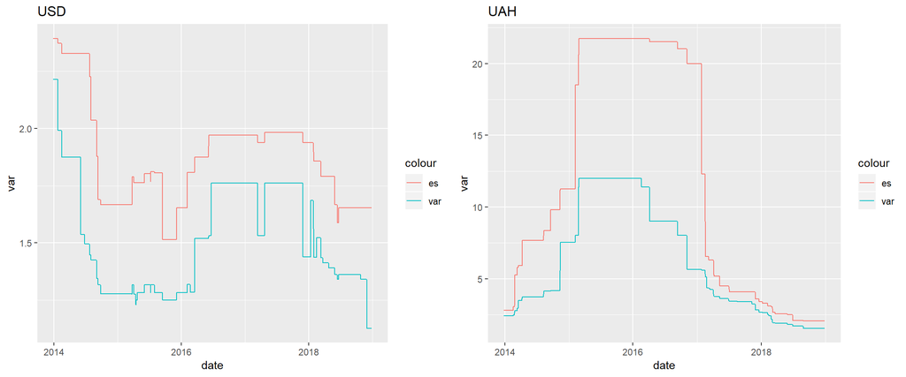

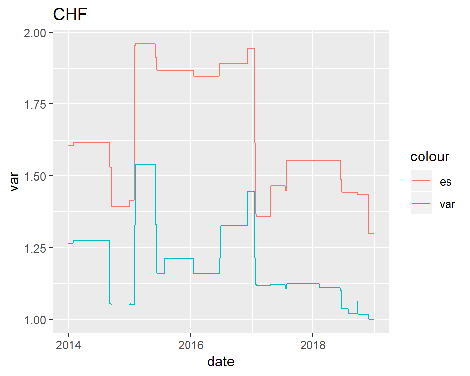

Z wykresu można wyczytać, że VAR dla dolara waha się mniej więcej od wartości 1.25 do 1.75. Podobnie jest dla franka z wahaniami od 1.00 do 1.50. ES dla obu walut raczej nie przekracza poziomu 2%.  
Hrywna natomiast jest “poza skalą” w porównaniu do dolara czy franka. Var na poziomie ponad 10%. a ES ponad 20%. Bardzo dobrze obrazuje to problem ukraińsko-rosyjski, który po walutach wnioskując, już się wycisza.  
Dla ukazania skali różnic pomiędzy walutami, poniżej znajdują się one na jednym wykresie.

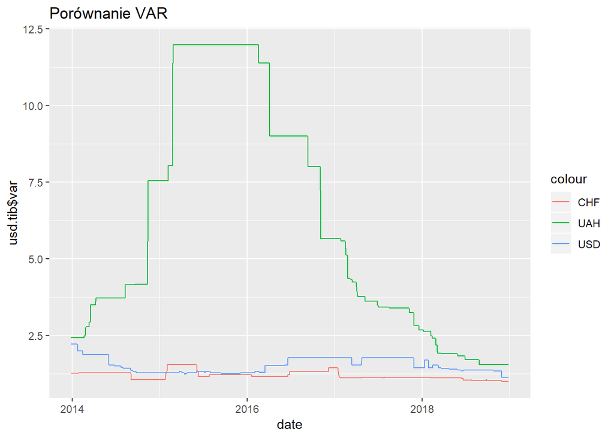

Jak widać różnice są ogromne.

# Metoda historyczna z wagami

Funkcja licząca **VAR** oraz **ES**.  
**rr**- stopy zwrotu, **window**- szerokość okna, **qq**- kwantyl, **importance**- parametr regulujący rozkład wag (domyślnie ustawiony na wartość 0.99)

```r
var.hull <- function(rr, window = 500, qq = 0.99, importance = 0.99)
{
  #wagi dla metody hull'a
  imp <- function(q, n)
  {
    sapply(1:n, function(i) ((1-q) * q^(n-i))/(1 - q^n))
  }
  require(distr)
  require(dplyr)
  pi <- imp(q = importance, n = window)
  tibb <- tibble("xi" = rr, "pi" = rep(pi, length.out = length(rr)))

  output <- tibble("i" = NA, "var" = NA, "es" = NA)
  for (i in 1:(length(rr) - window))
    {
      tib <- tibb[i:(i + window - 1), ]
      tib[, 2] <- pi
      D <- DiscreteDistribution(supp = pull(tib[, 1]), prob = pi)
      qD <- q(D)
      quant <- qD(qq) #var

      tib2 <- tib %>%
        filter(xi > quant) %>%
        mutate(pi = pi/(1 - qq))

      tib3 <- bind_rows(tib2, tib[which(tib$xi == quant), ])
      tib3[(dim(tib2)[1] + 1), 2] <- 1-sum(tib2$pi)

      es <- sum(tib3[, 1] * tib3[, 2])

      output <- bind_rows(output, tibble("i" = i, "var" = quant, "es" = es))
    }

  output <- output[-1, ]
  return(output)
}
```

Funkcja zwraca numer scenariusza, var dla danego scenariusza oraz es dla danego scenariusza jako ramkę danych.

Poniżej output dla powyższej funkcji dla każdej z walut z argumentami domyślnymi

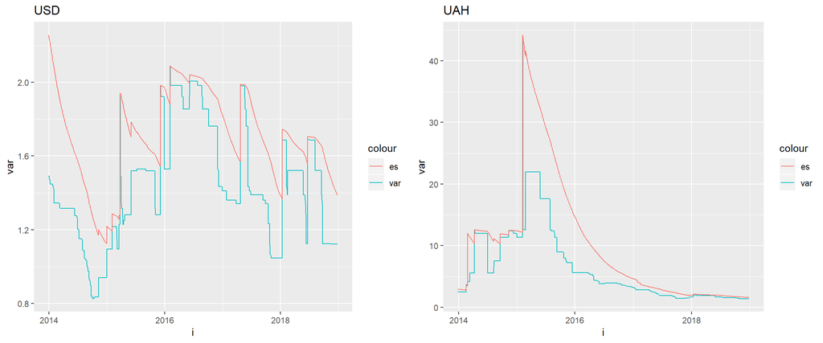

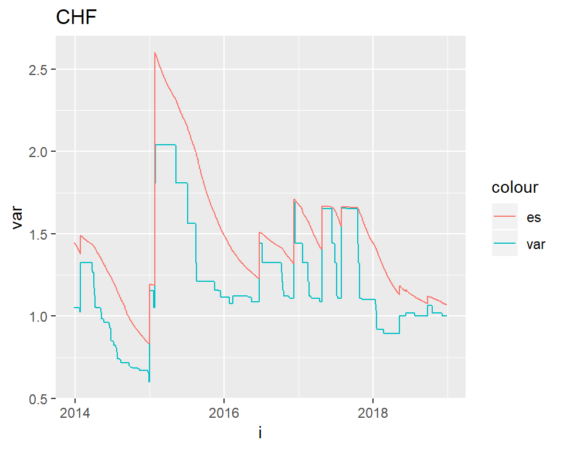

Komentarz do tych wykresów w zasadzie jest podobny jak w klasycznej metodzie historycznej. Od razu jednak widać, że wykresy znacząco różnią się od tych z poprzedniej metody. Uwzględnienie starzenia się danych daje zupełnie inne spojrzenie na problem. Lepiej pokazane będzie to w podsumowaniu, gdzie wszystkie metody zostaną zestawione oraz porównane na jednym wykresie. Ponownie, dla ukazania skali różnic- wykres z wartościami VAR wszystkich walut.

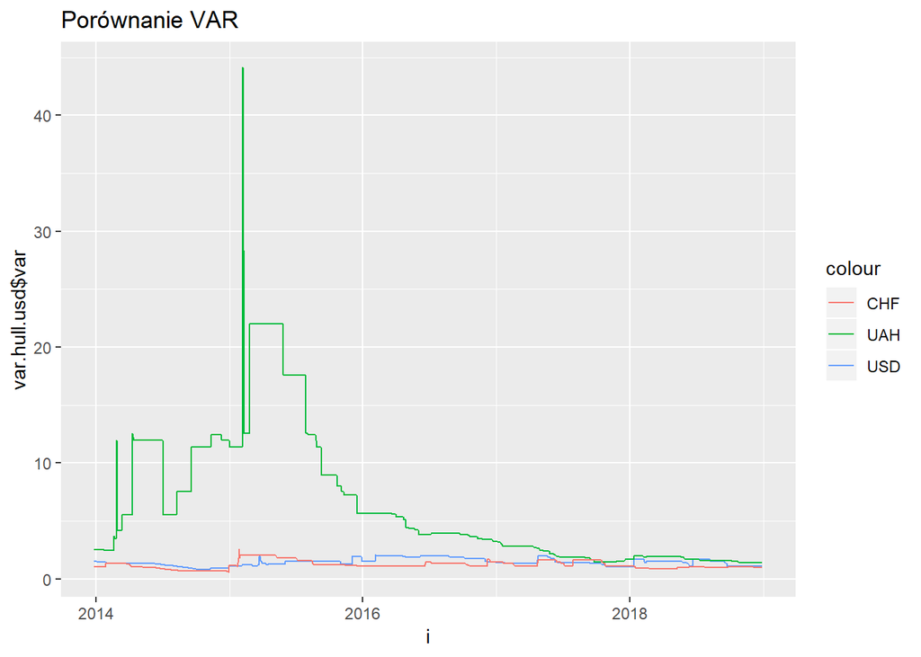

# Metoda bootstrap

Funckja:  
**rr**- stopy zwrotu, **window**- szerokość okna, **qq**- kwantyl, **n**- liczba symualcji na jedno okno, **s**- liczba elementów do wylosowania)

```r
var.boot <- function(rr, window = 500, qq = 0.99, n = 20, s = 600)
{
  var.es.output <- data.frame("var" = NA, "es" = NA)

  for (i in 1:(length(rr) - window))
  {
    foo.window <- rr[i:(i+window-1)]

    la.output <- sapply(1:n, function(x)
      {
        foo.sample <- sample(foo.window, s, replace = TRUE)
        var <- quantile(foo.sample, qq)
        es <- mean(foo.sample[which(foo.sample > var)])
        return(c(var, es))
      })
    var.es <- list("var" = la.output[1, ], "es" = la.output[2, ])
    var.es.output <- rbind(var.es.output, t(as.data.frame(mapply(mean, var.es))))
  }
  rownames(var.es.output) <- NULL
  var.es.output <- var.es.output[-1, ]
  return(var.es.output)
}
```

Funkcja zwraca ramkę danych zawierającą wyliczony VAR oraz ES dla poszczególnych okien.

Poniżej output dla powyższej funkcji dla każdej z walut z argumentami domyślnymi

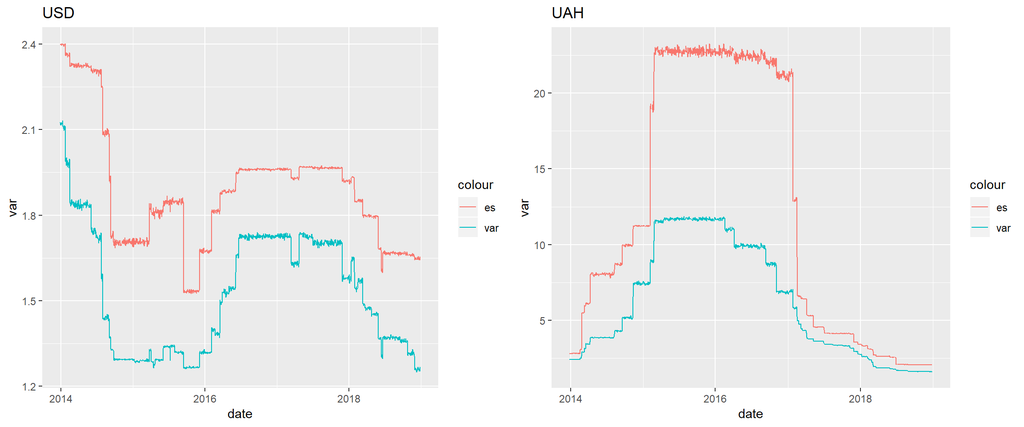

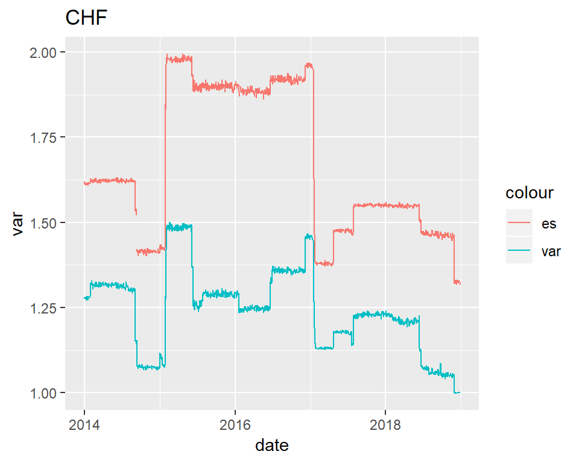

W tej metodzie Wyniki są bardzo zbliżone do klasycznej metody historycznej. Nie jest to zdziwieniem, ze względu na to, że jest to tylko modyfikacja tej metody.  
Tak jak poprzednio było wspomniane- różnice między metodami będą lepiej zobrazowane w podsumowaniu.  
Ponownie też, poniżej znajduje się porównanie VAR’ów dla wszyskich trzech walut.

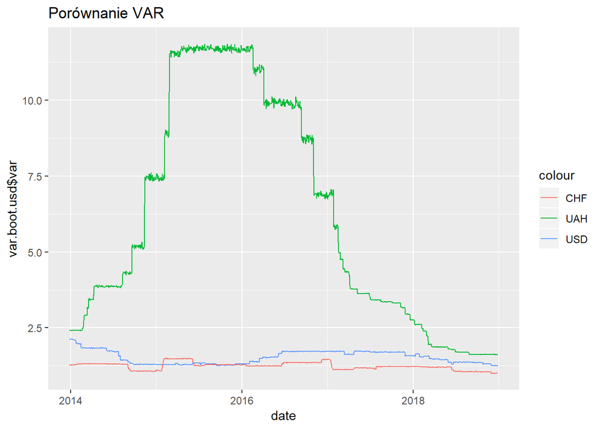

# Porównianie VAR/ES

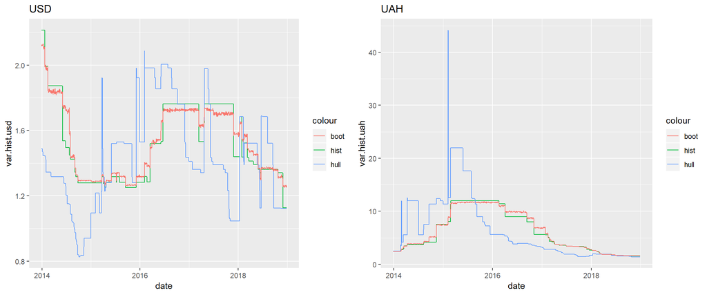

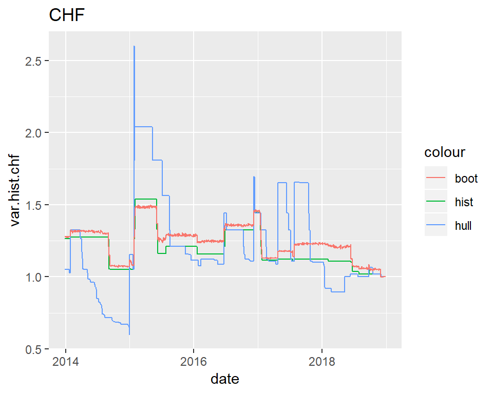

Widać dokładnie że metody historyczna oraz bootstrap’owa dają bardzo podobne wyniki. Metoda uwględniająca wagi daje już zupełnie inne wyniki. Skuteczność metod sprawdzona zostanie za pomocą dwóch testów w następnej części pracy.  
Tak jak wcześniej było mówione hrywna ukraińska jest najbardziej ryzykowną walutą do inwestowania. Ponownie, nie jest to zaskoczeniem. Wzięta została do pracy włąśnie z powodu słabej pozycji na rynku.

# Backtesting

Poniżej pokazane są funkcje służące do przeprowadzania testów kolejno kupca oraz wartości rzeczywistych.

```r
kupiec.bt <- function(rr, var, window = 500)
{
  kbt <- sapply(1:(length(var)), function(i) sum(var[i] < rr[(i):(i+ window - 1)]))
  k <- table(kbt)
  s <- sum(k[which(as.numeric(names(k)) < 10 & as.numeric(names(k)) > 0)])/length(var)
  return(s)
}

realvalue.bt <- function(rr, var, window = 500)
{
  sum(rr[(window + 1):length(rr)] < var)/length(rr[(window + 1):length(rr)])
}
```

| Testkupca | Testkupca hist | Testkupca hull | Testkupca boot |  |
| --- | --- | --- | --- | --- |
| USD | 1 | 0.6737926 | 1 |  |
| UAH | 1 | 0.5225653 | 1 |  |
| CHF | 1 | 0.7632621 | 1 |  |

| Test wartości rzeczywistych | Test wartości rzeczywistych hist | Test wartości rzeczywistych hull | Test wartości rzeczywistych boot |  |
| --- | --- | --- | --- | --- |
| USD | 0.9889153 | 0.9857482 | 0.9904988 |  |
| UAH | 0.9873317 | 0.9881235 | 0.9873317 |  |
| CHF | 0.9897070 | 0.9897070 | 0.9904988 |  |

Im wynikom bliżej do wartości $1$ tym dana metoda jest bardziej skuteczna.

Wyniki dla testu wartości rzeczywistych oscylujące mniej więcej w okolicach 99% są bardzo dobrym wynikiem.  
W teście kupca wartości dla metod historycznych oraz bootstrap’owych wynoszą 1 co jest wynikiem spodziewanym- sposób w jaki działa ten test nie pozwala na inny rezultat. Dla meotdy hull’a natomiast test kupca sugerowałby stosunkowo słabe dopasowanie. Test wartości rzeczywistych jednak wskazuje na to, że metoda wg hull’a działa nienajgorzej